# Optimal Treatment Analysis

## Outcome Variable

**Outcome Variable:** whz

## Predictor Variables

**Intervention Variable:** impfloor

**Adjustment Set:**

- arm
- sex
- W_mage
- meducyrs
- feducyrs
- hhwealth_quart
- hfoodsec
- W_mhtcm
- W_mwtkg
- W_mbmi
- W_nrooms
- W_nchldlt5
- W_parity
- impsan
- safeh20
- delta_W_mage
- delta_meducyrs
- delta_feducyrs
- delta_hhwealth_quart
- delta_hfoodsec
- delta_W_mhtcm
- delta_W_mwtkg
- delta_W_mbmi
- delta_W_nrooms
- delta_W_nchldlt5
- delta_W_parity
- delta_impsan
- delta_safeh20

## Stratifying Variables

The analysis was stratified on these variable(s):

- agecat
- studyid
- country

## Data Summary

| agecat | studyid | country | impfloor | n_cell | n |
| --- | --- | --- | --- | --- | --- |
| Birth | CMC-V-BCS-2002 | INDIA | 1 | 68 | 68 |
| Birth | CMC-V-BCS-2002 | INDIA | 0 | 0 | 68 |
| Birth | CONTENT | PERU | 1 | 2 | 2 |
| Birth | CONTENT | PERU | 0 | 0 | 2 |
| Birth | GMS-Nepal | NEPAL | 1 | 97 | 503 |
| Birth | GMS-Nepal | NEPAL | 0 | 406 | 503 |
| Birth | IRC | INDIA | 1 | 253 | 253 |
| Birth | IRC | INDIA | 0 | 0 | 253 |
| Birth | JiVitA-3 | BANGLADESH | 1 | 1215 | 17966 |
| Birth | JiVitA-3 | BANGLADESH | 0 | 16751 | 17966 |
| Birth | JiVitA-4 | BANGLADESH | 1 | 271 | 2394 |
| Birth | JiVitA-4 | BANGLADESH | 0 | 2123 | 2394 |
| Birth | MAL-ED | BANGLADESH | 1 | 185 | 201 |
| Birth | MAL-ED | BANGLADESH | 0 | 16 | 201 |
| Birth | MAL-ED | BRAZIL | 1 | 55 | 57 |
| Birth | MAL-ED | BRAZIL | 0 | 2 | 57 |
| Birth | MAL-ED | INDIA | 1 | 33 | 39 |
| Birth | MAL-ED | INDIA | 0 | 6 | 39 |
| Birth | MAL-ED | NEPAL | 1 | 8 | 24 |
| Birth | MAL-ED | NEPAL | 0 | 16 | 24 |
| Birth | MAL-ED | PERU | 1 | 37 | 210 |
| Birth | MAL-ED | PERU | 0 | 173 | 210 |
| Birth | MAL-ED | SOUTH AFRICA | 1 | 86 | 95 |
| Birth | MAL-ED | SOUTH AFRICA | 0 | 9 | 95 |
| Birth | MAL-ED | TANZANIA, UNITED REPUBLIC OF | 1 | 5 | 111 |
| Birth | MAL-ED | TANZANIA, UNITED REPUBLIC OF | 0 | 106 | 111 |
| Birth | NIH-Birth | BANGLADESH | 1 | 505 | 572 |
| Birth | NIH-Birth | BANGLADESH | 0 | 67 | 572 |
| Birth | NIH-Crypto | BANGLADESH | 1 | 542 | 707 |
| Birth | NIH-Crypto | BANGLADESH | 0 | 165 | 707 |

[output cut: 66 more lines]

The following strata were considered:

- agecat: 24 months, studyid: CMC-V-BCS-2002, country: INDIA
- agecat: 24 months, studyid: CONTENT, country: PERU
- agecat: 24 months, studyid: GMS-Nepal, country: NEPAL
- agecat: 24 months, studyid: IRC, country: INDIA
- agecat: 24 months, studyid: JiVitA-3, country: BANGLADESH
- agecat: 24 months, studyid: JiVitA-4, country: BANGLADESH
- agecat: 24 months, studyid: MAL-ED, country: BANGLADESH
- agecat: 24 months, studyid: MAL-ED, country: BRAZIL
- agecat: 24 months, studyid: MAL-ED, country: INDIA
- agecat: 24 months, studyid: MAL-ED, country: NEPAL
- agecat: 24 months, studyid: MAL-ED, country: PERU
- agecat: 24 months, studyid: MAL-ED, country: SOUTH AFRICA
- agecat: 24 months, studyid: MAL-ED, country: TANZANIA, UNITED REPUBLIC OF
- agecat: 24 months, studyid: NIH-Birth, country: BANGLADESH
- agecat: 24 months, studyid: NIH-Crypto, country: BANGLADESH
- agecat: 24 months, studyid: PROVIDE, country: BANGLADESH
- agecat: 6 months, studyid: CMC-V-BCS-2002, country: INDIA
- agecat: 6 months, studyid: CONTENT, country: PERU
- agecat: 6 months, studyid: GMS-Nepal, country: NEPAL
- agecat: 6 months, studyid: IRC, country: INDIA
- agecat: 6 months, studyid: JiVitA-3, country: BANGLADESH
- agecat: 6 months, studyid: JiVitA-4, country: BANGLADESH
- agecat: 6 months, studyid: MAL-ED, country: BANGLADESH
- agecat: 6 months, studyid: MAL-ED, country: BRAZIL
- agecat: 6 months, studyid: MAL-ED, country: INDIA
- agecat: 6 months, studyid: MAL-ED, country: NEPAL
- agecat: 6 months, studyid: MAL-ED, country: PERU
- agecat: 6 months, studyid: MAL-ED, country: SOUTH AFRICA
- agecat: 6 months, studyid: MAL-ED, country: TANZANIA, UNITED REPUBLIC OF
- agecat: 6 months, studyid: NIH-Birth, country: BANGLADESH
- agecat: 6 months, studyid: NIH-Crypto, country: BANGLADESH
- agecat: 6 months, studyid: PROVIDE, country: BANGLADESH
- agecat: Birth, studyid: CMC-V-BCS-2002, country: INDIA
- agecat: Birth, studyid: CONTENT, country: PERU
- agecat: Birth, studyid: GMS-Nepal, country: NEPAL
- agecat: Birth, studyid: IRC, country: INDIA
- agecat: Birth, studyid: JiVitA-3, country: BANGLADESH
- agecat: Birth, studyid: JiVitA-4, country: BANGLADESH
- agecat: Birth, studyid: MAL-ED, country: BANGLADESH
- agecat: Birth, studyid: MAL-ED, country: BRAZIL
- agecat: Birth, studyid: MAL-ED, country: INDIA
- agecat: Birth, studyid: MAL-ED, country: NEPAL
- agecat: Birth, studyid: MAL-ED, country: PERU
- agecat: Birth, studyid: MAL-ED, country: SOUTH AFRICA
- agecat: Birth, studyid: MAL-ED, country: TANZANIA, UNITED REPUBLIC OF
- agecat: Birth, studyid: NIH-Birth, country: BANGLADESH
- agecat: Birth, studyid: NIH-Crypto, country: BANGLADESH
- agecat: Birth, studyid: PROVIDE, country: BANGLADESH

### Dropped Strata

- agecat: Birth, studyid: CMC-V-BCS-2002, country: INDIA
- agecat: Birth, studyid: CONTENT, country: PERU
- agecat: Birth, studyid: IRC, country: INDIA
- agecat: Birth, studyid: MAL-ED, country: BRAZIL
- agecat: 6 months, studyid: CMC-V-BCS-2002, country: INDIA
- agecat: 6 months, studyid: IRC, country: INDIA
- agecat: 6 months, studyid: MAL-ED, country: BRAZIL
- agecat: 24 months, studyid: CMC-V-BCS-2002, country: INDIA
- agecat: 24 months, studyid: IRC, country: INDIA
- agecat: 24 months, studyid: MAL-ED, country: BRAZIL

## Methods Detail

We’re interested in the causal parameters $E[Y_a]$ for all values of $a \in \mathcal{A}$. These parameters represent the mean outcome if, possibly contrary to fact, we intervened to set all units to have $A=a$. Under the randomization and positivity assumptions, these are identified by the statistical parameters $\psi_a=E_W[E_{Y|A,W}(Y|A=a,W)]$. In addition, we’re interested in the mean of $Y$, $E[Y]$ under no intervention (the observed mean). We will estimate these parameters by using SuperLearner to fit the relevant likelihood factors – $E_{Y|A,W}(Y|A=a,W)$ and $p(A=a|W)$, and then updating our likelihood fit using a joint TMLE.

For unadjusted analyses ($W=\{\}$), initial likelihoods were estimated using Lrnr_glm to estimate the simple $E(Y|A)$ and Lrnr_mean to estimate $p(A)$. For adjusted analyses, a small library containing Lrnr_glmnet, Lrnr_xgboost, and Lrnr_mean was used.

Having estimated these parameters, we will then use the delta method to estimate relative risks and attributable risks relative to a prespecified baseline level of $A$.

# Results Detail

## Results Plots

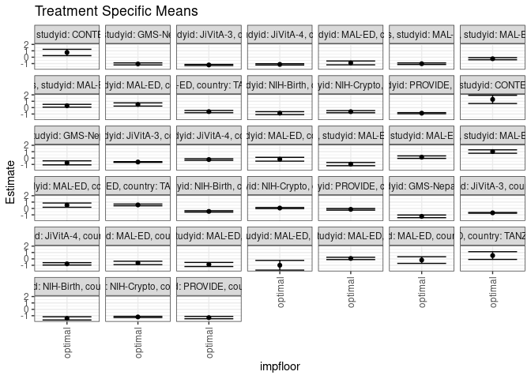

## Results Table

### Parameter: TSM

| agecat | studyid | country | intervention_level | baseline_level | estimate | ci_lower | ci_upper |
| --- | --- | --- | --- | --- | --- | --- | --- |
| Birth | GMS-Nepal | NEPAL | optimal | observed | -1.2339036 | -1.4434117 | -1.0243955 |
| Birth | JiVitA-3 | BANGLADESH | optimal | observed | -0.6834891 | -0.7380159 | -0.6289622 |
| Birth | JiVitA-4 | BANGLADESH | optimal | observed | -0.7763528 | -0.9621347 | -0.5905708 |
| Birth | MAL-ED | BANGLADESH | optimal | observed | -0.6305948 | -0.8988054 | -0.3623841 |
| Birth | MAL-ED | INDIA | optimal | observed | -0.8741435 | -1.1920104 | -0.5562766 |
| Birth | MAL-ED | NEPAL | optimal | observed | -0.9958444 | -1.7592488 | -0.2324400 |
| Birth | MAL-ED | PERU | optimal | observed | 0.0718478 | -0.1106864 | 0.2543820 |
| Birth | MAL-ED | SOUTH AFRICA | optimal | observed | -0.1815734 | -0.7022210 | 0.3390741 |
| Birth | MAL-ED | TANZANIA, UNITED REPUBLIC OF | optimal | observed | 0.5213848 | -0.0834985 | 1.1262681 |
| Birth | NIH-Birth | BANGLADESH | optimal | observed | -1.4177374 | -1.6658219 | -1.1696530 |
| Birth | NIH-Crypto | BANGLADESH | optimal | observed | -1.1946267 | -1.2879412 | -1.1013121 |
| Birth | PROVIDE | BANGLADESH | optimal | observed | -1.2977895 | -1.4801794 | -1.1153996 |
| 6 months | CONTENT | PERU | optimal | observed | 1.2883340 | 0.6412251 | 1.9354428 |
| 6 months | GMS-Nepal | NEPAL | optimal | observed | -0.7537992 | -1.0689458 | -0.4386525 |
| 6 months | JiVitA-3 | BANGLADESH | optimal | observed | -0.6185279 | -0.6772825 | -0.5597734 |
| 6 months | JiVitA-4 | BANGLADESH | optimal | observed | -0.2349000 | -0.3644810 | -0.1053191 |
| 6 months | MAL-ED | BANGLADESH | optimal | observed | -0.1879361 | -0.4858041 | 0.1099320 |
| 6 months | MAL-ED | INDIA | optimal | observed | -0.9454052 | -1.1988347 | -0.6919758 |
| 6 months | MAL-ED | NEPAL | optimal | observed | 0.1414011 | -0.0533691 | 0.3361712 |
| 6 months | MAL-ED | PERU | optimal | observed | 1.0169858 | 0.7477803 | 1.2861914 |
| 6 months | MAL-ED | SOUTH AFRICA | optimal | observed | 0.5214997 | 0.1878752 | 0.8551243 |
| 6 months | MAL-ED | TANZANIA, UNITED REPUBLIC OF | optimal | observed | 0.5559045 | 0.4207844 | 0.6910247 |
| 6 months | NIH-Birth | BANGLADESH | optimal | observed | -0.4587794 | -0.5661598 | -0.3513989 |
| 6 months | NIH-Crypto | BANGLADESH | optimal | observed | 0.0662725 | -0.0242753 | 0.1568203 |
| 6 months | PROVIDE | BANGLADESH | optimal | observed | -0.1367487 | -0.2604925 | -0.0130050 |
| 24 months | CONTENT | PERU | optimal | observed | 0.7422036 | 0.2442962 | 1.2401109 |
| 24 months | GMS-Nepal | NEPAL | optimal | observed | -1.0503590 | -1.2111276 | -0.8895904 |
| 24 months | JiVitA-3 | BANGLADESH | optimal | observed | -1.2137407 | -1.3021728 | -1.1253086 |
| 24 months | JiVitA-4 | BANGLADESH | optimal | observed | -1.1234613 | -1.2237861 | -1.0231365 |
| 24 months | MAL-ED | BANGLADESH | optimal | observed | -0.8947877 | -1.1953336 | -0.5942418 |
| 24 months | MAL-ED | INDIA | optimal | observed | -1.0174321 | -1.1388255 | -0.8960387 |
| 24 months | MAL-ED | NEPAL | optimal | observed | -0.2397996 | -0.4035356 | -0.0760637 |
| 24 months | MAL-ED | PERU | optimal | observed | 0.2932480 | 0.0761811 | 0.5103149 |
| 24 months | MAL-ED | SOUTH AFRICA | optimal | observed | 0.4905979 | 0.2380924 | 0.7431034 |
| 24 months | MAL-ED | TANZANIA, UNITED REPUBLIC OF | optimal | observed | -0.6219240 | -0.7997690 | -0.4440791 |
| 24 months | NIH-Birth | BANGLADESH | optimal | observed | -0.8658012 | -1.0957239 | -0.6358786 |
| 24 months | NIH-Crypto | BANGLADESH | optimal | observed | -0.6345290 | -0.8025403 | -0.4665177 |
| 24 months | PROVIDE | BANGLADESH | optimal | observed | -0.8707157 | -0.9565710 | -0.7848604 |

### Parameter: E(Y)

| agecat | studyid | country | intervention_level | baseline_level | estimate | ci_lower | ci_upper |
| --- | --- | --- | --- | --- | --- | --- | --- |
| Birth | GMS-Nepal | NEPAL | observed | observed | -1.0860636 | -1.1830454 | -0.9890818 |
| Birth | JiVitA-3 | BANGLADESH | observed | observed | -0.7773511 | -0.7963777 | -0.7583245 |
| Birth | JiVitA-4 | BANGLADESH | observed | observed | -0.6882498 | -0.7406539 | -0.6358456 |
| Birth | MAL-ED | BANGLADESH | observed | observed | -0.9728358 | -1.1217009 | -0.8239707 |
| Birth | MAL-ED | INDIA | observed | observed | -0.9441026 | -1.2397919 | -0.6484132 |
| Birth | MAL-ED | NEPAL | observed | observed | -0.8087500 | -1.1914221 | -0.4260779 |
| Birth | MAL-ED | PERU | observed | observed | -0.0468095 | -0.1738806 | 0.0802616 |
| Birth | MAL-ED | SOUTH AFRICA | observed | observed | -0.1729474 | -0.4186222 | 0.0727275 |
| Birth | MAL-ED | TANZANIA, UNITED REPUBLIC OF | observed | observed | 0.7690991 | 0.5714748 | 0.9667234 |
| Birth | NIH-Birth | BANGLADESH | observed | observed | -1.3448514 | -1.4396716 | -1.2500312 |
| Birth | NIH-Crypto | BANGLADESH | observed | observed | -1.2441513 | -1.3281130 | -1.1601897 |
| Birth | PROVIDE | BANGLADESH | observed | observed | -1.2984586 | -1.3752758 | -1.2216415 |
| 6 months | CONTENT | PERU | observed | observed | 1.0644279 | 0.9468682 | 1.1819876 |
| 6 months | GMS-Nepal | NEPAL | observed | observed | -0.6273772 | -0.7253868 | -0.5293676 |
| 6 months | JiVitA-3 | BANGLADESH | observed | observed | -0.5926720 | -0.6122891 | -0.5730549 |
| 6 months | JiVitA-4 | BANGLADESH | observed | observed | -0.3901347 | -0.4273932 | -0.3528762 |
| 6 months | MAL-ED | BANGLADESH | observed | observed | -0.1333333 | -0.2623761 | -0.0042906 |
| 6 months | MAL-ED | INDIA | observed | observed | -0.7102872 | -0.8371659 | -0.5834085 |
| 6 months | MAL-ED | NEPAL | observed | observed | 0.1281441 | -0.0056126 | 0.2619008 |
| 6 months | MAL-ED | PERU | observed | observed | 1.0512099 | 0.9285617 | 1.1738581 |
| 6 months | MAL-ED | SOUTH AFRICA | observed | observed | 0.5404351 | 0.3867005 | 0.6941696 |
| 6 months | MAL-ED | TANZANIA, UNITED REPUBLIC OF | observed | observed | 0.5355782 | 0.4032519 | 0.6679046 |
| 6 months | NIH-Birth | BANGLADESH | observed | observed | -0.4447399 | -0.5354039 | -0.3540758 |
| 6 months | NIH-Crypto | BANGLADESH | observed | observed | 0.0297622 | -0.0491685 | 0.1086930 |
| 6 months | PROVIDE | BANGLADESH | observed | observed | -0.1990907 | -0.2817968 | -0.1163845 |
| 24 months | CONTENT | PERU | observed | observed | 0.5902439 | 0.4560143 | 0.7244735 |
| 24 months | GMS-Nepal | NEPAL | observed | observed | -1.1990840 | -1.3039914 | -1.0941766 |
| 24 months | JiVitA-3 | BANGLADESH | observed | observed | -1.2970420 | -1.3203145 | -1.2737694 |
| 24 months | JiVitA-4 | BANGLADESH | observed | observed | -1.2232311 | -1.2550891 | -1.1913732 |
| 24 months | MAL-ED | BANGLADESH | observed | observed | -0.8192925 | -0.9412667 | -0.6973182 |
| 24 months | MAL-ED | INDIA | observed | observed | -0.9516520 | -1.0670654 | -0.8362385 |
| 24 months | MAL-ED | NEPAL | observed | observed | -0.3471493 | -0.4618867 | -0.2324120 |
| 24 months | MAL-ED | PERU | observed | observed | 0.1111982 | -0.0118399 | 0.2342362 |
| 24 months | MAL-ED | SOUTH AFRICA | observed | observed | 0.4090301 | 0.2879441 | 0.5301161 |
| 24 months | MAL-ED | TANZANIA, UNITED REPUBLIC OF | observed | observed | 0.0477437 | -0.0779935 | 0.1734809 |
| 24 months | NIH-Birth | BANGLADESH | observed | observed | -0.9106710 | -1.0090143 | -0.8123277 |
| 24 months | NIH-Crypto | BANGLADESH | observed | observed | -0.6103502 | -0.7050157 | -0.5156847 |
| 24 months | PROVIDE | BANGLADESH | observed | observed | -0.8928670 | -0.9755153 | -0.8102187 |

### Parameter: PAR

| agecat | studyid | country | intervention_level | baseline_level | estimate | ci_lower | ci_upper |
| --- | --- | --- | --- | --- | --- | --- | --- |
| Birth | GMS-Nepal | NEPAL | optimal | observed | 0.1478400 | -0.0420006 | 0.3376806 |
| Birth | JiVitA-3 | BANGLADESH | optimal | observed | -0.0938621 | -0.1461593 | -0.0415648 |
| Birth | JiVitA-4 | BANGLADESH | optimal | observed | 0.0881030 | -0.0887785 | 0.2649845 |
| Birth | MAL-ED | BANGLADESH | optimal | observed | -0.3422411 | -0.6323901 | -0.0520920 |
| Birth | MAL-ED | INDIA | optimal | observed | -0.0699591 | -0.2048889 | 0.0649707 |
| Birth | MAL-ED | NEPAL | optimal | observed | 0.1870944 | -0.3522145 | 0.7264032 |
| Birth | MAL-ED | PERU | optimal | observed | -0.1186573 | -0.2867204 | 0.0494057 |
| Birth | MAL-ED | SOUTH AFRICA | optimal | observed | 0.0086261 | -0.5294220 | 0.5466741 |
| Birth | MAL-ED | TANZANIA, UNITED REPUBLIC OF | optimal | observed | 0.2477143 | -0.3581349 | 0.8535635 |
| Birth | NIH-Birth | BANGLADESH | optimal | observed | 0.0728860 | -0.1587354 | 0.3045074 |
| Birth | NIH-Crypto | BANGLADESH | optimal | observed | -0.0495247 | -0.0980630 | -0.0009863 |
| Birth | PROVIDE | BANGLADESH | optimal | observed | -0.0006692 | -0.1713547 | 0.1700164 |
| 6 months | CONTENT | PERU | optimal | observed | -0.2239061 | -0.8493924 | 0.4015803 |
| 6 months | GMS-Nepal | NEPAL | optimal | observed | 0.1264220 | -0.1691410 | 0.4219850 |
| 6 months | JiVitA-3 | BANGLADESH | optimal | observed | 0.0258560 | -0.0312542 | 0.0829661 |
| 6 months | JiVitA-4 | BANGLADESH | optimal | observed | -0.1552346 | -0.2799260 | -0.0305433 |
| 6 months | MAL-ED | BANGLADESH | optimal | observed | 0.0546028 | -0.2078974 | 0.3171029 |
| 6 months | MAL-ED | INDIA | optimal | observed | 0.2351180 | -0.0258243 | 0.4960603 |
| 6 months | MAL-ED | NEPAL | optimal | observed | -0.0132570 | -0.1453944 | 0.1188805 |
| 6 months | MAL-ED | PERU | optimal | observed | 0.0342241 | -0.2002267 | 0.2686748 |
| 6 months | MAL-ED | SOUTH AFRICA | optimal | observed | 0.0189353 | -0.2849881 | 0.3228588 |
| 6 months | MAL-ED | TANZANIA, UNITED REPUBLIC OF | optimal | observed | -0.0203263 | -0.0572475 | 0.0165949 |
| 6 months | NIH-Birth | BANGLADESH | optimal | observed | 0.0140395 | -0.0469109 | 0.0749899 |
| 6 months | NIH-Crypto | BANGLADESH | optimal | observed | -0.0365103 | -0.0837880 | 0.0107675 |
| 6 months | PROVIDE | BANGLADESH | optimal | observed | -0.0623419 | -0.1526479 | 0.0279640 |
| 24 months | CONTENT | PERU | optimal | observed | -0.1519597 | -0.6433356 | 0.3394163 |
| 24 months | GMS-Nepal | NEPAL | optimal | observed | -0.1487250 | -0.2771800 | -0.0202700 |
| 24 months | JiVitA-3 | BANGLADESH | optimal | observed | -0.0833012 | -0.1681911 | 0.0015887 |
| 24 months | JiVitA-4 | BANGLADESH | optimal | observed | -0.0997698 | -0.1984468 | -0.0010928 |
| 24 months | MAL-ED | BANGLADESH | optimal | observed | 0.0754952 | -0.1811778 | 0.3321683 |
| 24 months | MAL-ED | INDIA | optimal | observed | 0.0657801 | 0.0073234 | 0.1242368 |
| 24 months | MAL-ED | NEPAL | optimal | observed | -0.1073497 | -0.2303442 | 0.0156448 |
| 24 months | MAL-ED | PERU | optimal | observed | -0.1820498 | -0.3579349 | -0.0061648 |
| 24 months | MAL-ED | SOUTH AFRICA | optimal | observed | -0.0815678 | -0.3265898 | 0.1634543 |
| 24 months | MAL-ED | TANZANIA, UNITED REPUBLIC OF | optimal | observed | 0.6696678 | 0.5159468 | 0.8233887 |
| 24 months | NIH-Birth | BANGLADESH | optimal | observed | -0.0448698 | -0.2454637 | 0.1557242 |
| 24 months | NIH-Crypto | BANGLADESH | optimal | observed | 0.0241788 | -0.1226616 | 0.1710192 |
| 24 months | PROVIDE | BANGLADESH | optimal | observed | -0.0221513 | -0.0466927 | 0.0023901 |